# **Example: *hal_i3c_ibi_controller***

**Example version:** 2.0.3

[figure not shown]

How to handle In-Band Interrupts (IBI) from multiple targets using the I3C bus protocol and STM32 HAL API in interrupt-driven (IT) mode.

**Note that the terminology Controller/Target characterizes the role taken by each device in the I3C communication, corresponding respectively to the I3C master and I3C slave in legacy terminology.**

## **1. Detailed scenario**

This example demonstrates controller-side In-Band Interrupt (IBI) handling for multiple already dynamically addressed targets using the I3C protocol and STM32 HAL API in interrupt-driven (IT) mode. By default, the scenario is set up for two targets connected to the controller.

**Initialization phase**: At main program start, the `mx_system_init()` function is called. It initializes the peripherals, nonvolatile memory (such as flash memory, NVM, or external memories), MPU regions (if applicable), the system clock, and the SysTick.

The application executes the following **example steps**:

**Step 1**: Configures and initializes the I3C instance and the NVIC. Registers the user callbacks for I3C target events.

**Step 2**: Starts the DAA/ENTDAA procedure by sending ENTDAA, receives each target’s BCR/DCR/PID payload, assigns a dynamic address sequentially, and repeats until all responding targets are processed or no further responses occur.

**Step 3**: Enables IBI notification and waits for either IBI completion or transfer error.

**Step 4**: Verifies the received IBI: CCC info, payload length, target address, and payload value to ensure correct processing.

The communication status is reported via the status LED and the variable ExecStatus.

**End of example**: When DAA completes successfully and at least one IBI is received and verified, the scenario is considered complete. If the maximum number of attempts is reached, an error status is reported.

If you enable **`USE_TRACE`**, you can follow these execution steps in the terminal logs:

```
[INFO] Step 1: Device initialization COMPLETED.
[INFO] Step 2: DAA process COMPLETED. Number of targets detected: <N>
[INFO] Step 3: IBI process COMPLETED.
[INFO] Step 4: All values received from the target are correct.
[ERROR] IBI payload length mismatch.
[ERROR] IBI payload value mismatch.
```

## **2. Example configuration**

[figure not shown]

This example demonstrates the following peripherals.

**I3C**: is configured as indicated below:

- The controller assigns dynamic addresses (default: 0x32 and 0x34) to two targets during ENTDAA. These addresses are set in the `TargetsDescriptor` array in the example. You can modify these values or add more addresses by updating the entries in the `TargetsDescriptor` array to support additional targets as needed.
- The bus usage, including the I3C bus and its duty cycle timings, is calculated by STM32CubeMX2 in accordance with the I3C initialization section of the reference manual.
- The I3C bus is configured to run at the maximum supported speed to demonstrate its highest performance. See `__I3C maximum speed__` in section 3.2 Specific board setups.
- The event and error interrupts of the I3C instance are configured and enabled in the NVIC.

To test this example with the target, you can use the corresponding *hal_i3c_ibi_target* example pack.

## **3. Hardware environment and setup**

### **3.1. Generic Setup**

- The controller board is connected to the target board through the two I3C lines and a common GND.

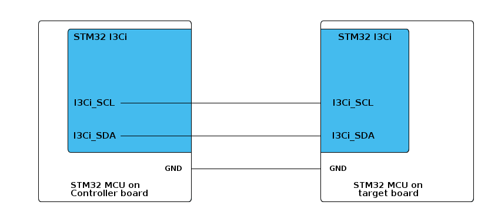

example_hal_i3c_ibi_controller-setup

### **3.2. Specific board setups**

The I3C serial clock (SCL) and data (SDA) lines can be observed by connecting an oscilloscope or a logic analyzer to the corresponding board connectors.

This section describes the exact hardware configurations of your project.

**On STM32C5 series.**

**I3C maximum speed**

The maximum speed configured for these series is 12,5MHz.

**On board NUCLEO-C542RC.**

| MCU pin | Signal name | User Label |
| --- | --- | --- |
| PA5 | GPIO | MX_STATUS_LED |
| PH0 | RCC_OSC_IN | OSC_IN |
| PH1 | RCC_OSC_OUT | OSC_OUT |
| PA2 | USART2_TX | PA2 |
| PB6 | I3C1_SCL | PB6 |
| PB7 | I3C1_SDA | PB7 |

**On board NUCLEO-C562RE.**

| MCU pin | Signal name | User Label |
| --- | --- | --- |
| PA5 | GPIO | MX_STATUS_LED |
| PH0 | RCC_OSC_IN | OSC_IN |
| PH1 | RCC_OSC_OUT | OSC_OUT |
| PA2 | USART2_TX | PA2 |
| PB6 | I3C1_SCL | PB6 |
| PB7 | I3C1_SDA | PB7 |

**On board NUCLEO-C5A3ZG.**

| MCU pin | Signal name | User Label |
| --- | --- | --- |
| PA5 | GPIO | MX_STATUS_LED |
| PH0 | RCC_OSC_IN | PH0_OSC_IN |
| PH1 | RCC_OSC_OUT | PH1_OSC_OUT |
| PA2 | USART2_TX | DBGIN_VCP_TX |
| PB6 | I3C1_SCL | PB6 |
| PB7 | I3C1_SDA | PB7 |

## **4. Troubleshooting**

[figure not shown]

Here are the points of attention for this specific example:

1. **Dynamic Address Assignment (DAA)**: DAA is started by the controller using the `ENTDAA` command, one of the I3C Common Command Codes (CCC), standard broadcast commands used to manage devices on the bus. The controller enumerates each target, which responds with its identification payload (PID, BCR, DCR). The controller then assigns a unique dynamic address to each target, which is used for all further private transfers. In this example, DAA completion and address verification are handled via interrupts (see Step 2).
2. **In-Band Interrupt (IBI)**: IBI is an I3C feature that allows a target to asynchronously request service from the controller over the I3C bus (no dedicated GPIO interrupt line). The controller can accept (ACK) or reject (NACK) the request. Depending on the target capability, an IBI can be sent with or without a short payload. If no IBI is observed, verify that the controller is configured to accept the target IBI request and that the target triggers an IBI after it has a valid dynamic address.
3. If there are no I3C signals observed, remember to check these points first:
   - The GND pins of the controller and target boards are connected.
   - Use the shortest possible wires between the boards to improve signal integrity.
4. For correct synchronization, always run the target application before running the controller. This ensures the target is ready to respond to the controller’s DAA request.

## **5. See Also**

[figure not shown]

The documentation of the drivers of the relevant STM32 series contains more detailed information.

For instance for the STM32C5 series: [HAL documentation](https://dev.st.com/stm32cube-docs/stm32c5xx-hal-drivers/latest/en/index.html).

More information about the STM32 ecosystem can be found in the [STM32 MCU Developer Zone](https://www.st.com/content/st_com/en/stm32-mcu-developer-zone/embedded-software.html).

## **6. License**

Copyright (c) 2026 STMicroelectronics.

This software is licensed under terms that can be found in the LICENSE file in the root directory of this software component. If no LICENSE file comes with this software, it is provided AS-IS.